# Price Analysis of New York Houses

## Exploratory Data Analysis

**Dataset:** House Prices of New York  
**Variable of Interest:** Age

```r
str(houses)
```

```
## 'data.frame':    1734 obs. of  17 variables:
##  $ Price        : int  132500 181115 109000 155000 86060 120000 153000 170000 90000 122900 ...
##  $ Lot.Size     : num  0.09 0.92 0.19 0.41 0.11 0.68 0.4 1.21 0.83 1.94 ...
##  $ Waterfront   : Factor w/ 2 levels "0","1": 1 1 1 1 1 1 1 1 1 1 ...
##  $ Age          : int  42 0 133 13 0 31 33 23 36 4 ...
##  $ Land.Value   : int  50000 22300 7300 18700 15000 14000 23300 14600 22200 21200 ...
##  $ New.Construct: Factor w/ 2 levels "0","1": 1 1 1 1 2 1 1 1 1 1 ...
##  $ Central.Air  : Factor w/ 2 levels "0","1": 1 1 1 1 2 1 1 1 1 1 ...
##  $ Fuel.Type    : Factor w/ 7 levels "Electric","Gas",..: 1 2 2 2 2 2 4 4 1 2 ...
##  $ Heat.Type    : Factor w/ 4 levels "Electric","Hot Air",..: 1 3 3 2 2 2 3 2 1 2 ...
##  $ Sewer.Type   : Factor w/ 3 levels "None/Unknown",..: 2 2 3 2 3 2 2 2 2 1 ...
##  $ Living.Area  : int  906 1953 1944 1944 840 1152 2752 1662 1632 1416 ...
##  $ Pct.College  : int  35 51 51 51 51 22 51 35 51 44 ...
##  $ Bedrooms     : int  2 3 4 3 2 4 4 4 3 3 ...
##  $ Fireplaces   : int  1 0 1 1 0 1 1 1 0 0 ...
##  $ Bathrooms    : num  1 2.5 1 1.5 1 1 1.5 1.5 1.5 1.5 ...
##  $ Rooms        : int  5 6 8 5 3 8 8 9 8 6 ...
##  $ Test         : Factor w/ 2 levels "0","1": 1 2 2 1 1 2 1 1 1 2 ...
```

```r
describe(houses[, c("Price" ,"Lot.Size", "Age", "Land.Value", "Living.Area", "Pct.College", "Bedrooms", "Fireplaces", "Bathrooms", "Rooms")], fast=TRUE)
```

```
##             vars    n      mean       sd  min      max    range      se
## Price          1 1734 211545.05 98553.81 5000 775000.0 770000.0 2366.73
## Lot.Size       2 1734      0.50     0.70    0     12.2     12.2    0.02
## Age            3 1734     28.26    29.86    0    225.0    225.0    0.72
## Land.Value     4 1734  34536.23 34980.94  200 412600.0 412400.0  840.05
## Living.Area    5 1734   1752.63   620.22  616   5228.0   4612.0   14.89
## Pct.College    6 1734     55.57    10.32   20     82.0     62.0    0.25
## Bedrooms       7 1734      3.15     0.82    1      7.0      6.0    0.02
## Fireplaces     8 1734      0.60     0.56    0      4.0      4.0    0.01
## Bathrooms      9 1734      1.90     0.66    0      4.5      4.5    0.02
## Rooms         10 1734      7.03     2.32    2     12.0     10.0    0.06
```

### Age vs Price

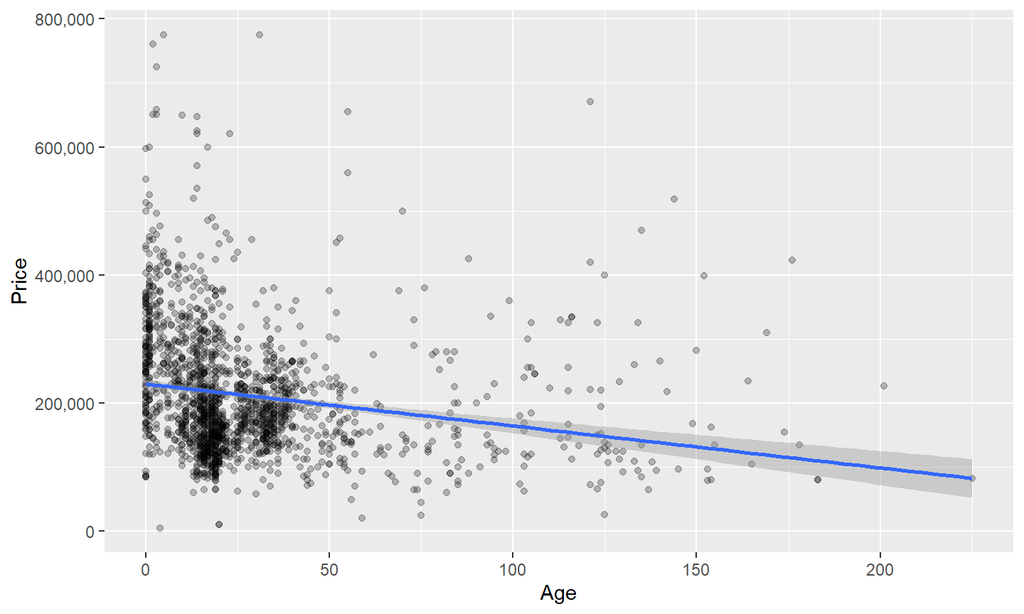

Although at the risk of extrapolation, one can infer that age and price are inversely related.

### Age vs Bedrooms

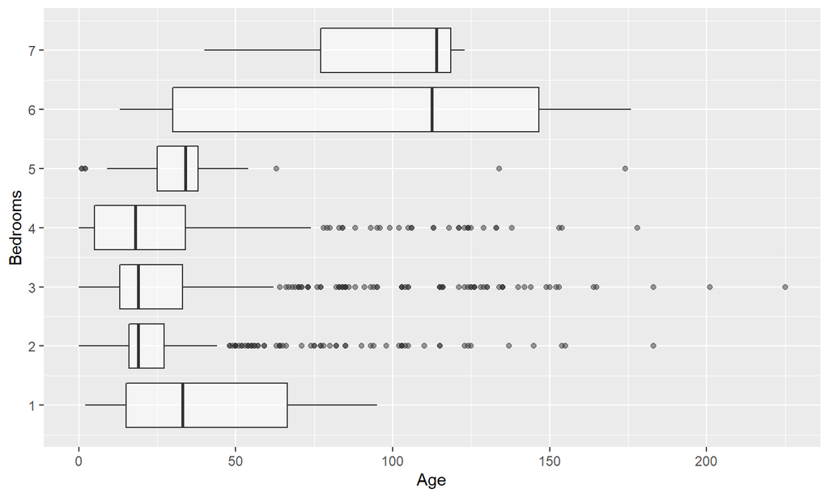

We observe that the houses with 5+ bedrooms are comparatively older that <5 bedrooms houses. For less than 5 bedroom houses, the trend is opposite. Four bedroom houses have been built more recently than 1 bedroom houses.

### Age vs Heat Type

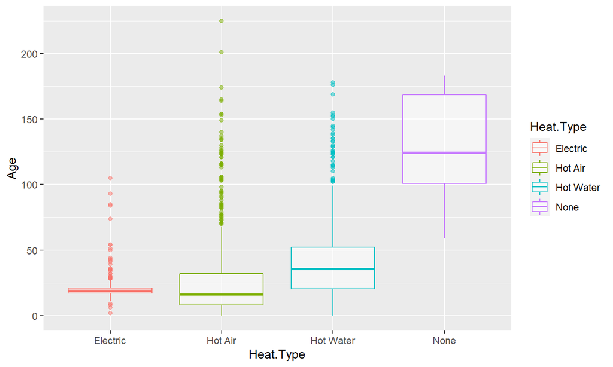

We observe here that houses with no heating system are older than ones that have a heating system.

```r
houses[,-which(sapply(df, class) == "factor")]
```

```
## data frame with 0 columns and 1734 rows
```

```r
houses_cor_mat = houses[,-which(sapply(df, class) == "factor")] %>%
  data.frame() %>%
  rownames_to_column(var = "var1") %>%
  gather(key = "var2", value = "cor", -var1)
```

## Analyzing the factors that determine the price of the house

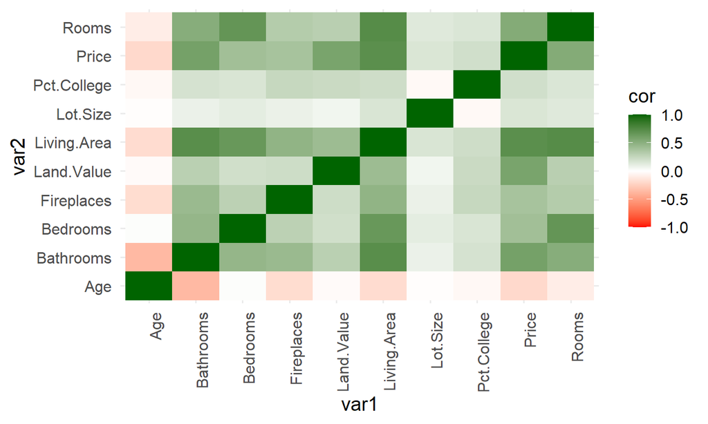

```r
# select numeric or integer type factors
temp = select(houses, - which(sapply(houses, class) == "factor"))
cor_mat = cor(temp)

melted_cor_mat = cor_mat %>%
  data.frame() %>%
  rownames_to_column(var = "var1") %>%
  gather(key = "var2", value = "cor", -var1)

# correlation matrix heatmap
melted_cor_mat %>% ggplot() +
  aes(x=var1, y=var2, fill=cor) +
  geom_tile() + theme_minimal(base_size = 15) +
  scale_fill_gradient2(
    low = "red", high = "darkgreen", mid = "white",
    midpoint = 0, limit = c(-1,1)) +
  theme(axis.text.x = element_text(angle = 90, hjust = 1))
```

```r
# interactive plot using 'qtlcharts'
iplotCorr(temp)
```

```
## Set screen size to height=700 x width=1000
```

[interactive chart not shown]

[figure not shown]

```r
lm = lm(Price ~ Living.Area, data = houses)

#plot(Price ~ Living.Area, data = housing)
#abline(lm, lwd = 3, col = "red")

houses %>% ggplot() +
  aes(y = Price, x = Living.Area) +
  geom_point(alpha = 0.25) +
  geom_smooth(method = "lm") +
  labs(x = "Age") +
  scale_y_continuous(labels = comma)
```

```r
summary(lm)
```

```
##
## Call:
## lm(formula = Price ~ Living.Area, data = houses)
##
## Residuals:
##     Min      1Q  Median      3Q     Max
## -277184  -39340   -7619   28376  553725
##
## Coefficients:
##              Estimate Std. Error t value Pr(>|t|)
## (Intercept) 12844.179   4973.493   2.583  0.00989 **
## Living.Area   113.373      2.675  42.378  < 2e-16 ***
## ---
## Signif. codes:  0 '***' 0.001 '**' 0.01 '*' 0.05 '.' 0.1 ' ' 1
##
## Residual standard error: 69070 on 1732 degrees of freedom
## Multiple R-squared:  0.5091, Adjusted R-squared:  0.5088
## F-statistic:  1796 on 1 and 1732 DF,  p-value: < 2.2e-16
```

```r
M0 = lm(Price ~ 1, data = houses)

M1 = lm(Price ~ ., data = houses)
```

```r
round(summary(M1)$coef,3)
```

```
##                          Estimate Std. Error t value Pr(>|t|)
## (Intercept)              7994.062  19604.816   0.408    0.684
## Lot.Size                 7554.997   2238.108   3.376    0.001
## Waterfront1            120237.097  15524.380   7.745    0.000
## Age                      -134.154     58.115  -2.308    0.021
## Land.Value                  0.927      0.048  19.491    0.000
## New.Construct1         -45650.453   7299.341  -6.254    0.000
## Central.Air1             9927.179   3474.258   2.857    0.004
## Fuel.TypeGas            10223.278  12128.326   0.843    0.399
## Fuel.TypeNone          -30023.683  34670.469  -0.866    0.387
## Fuel.TypeOil             6419.419  12869.599   0.499    0.618
## Fuel.TypeSolar          -4203.574  58643.987  -0.072    0.943
## Fuel.TypeUnknown/Other -53945.471  58525.780  -0.922    0.357
## Fuel.TypeWood          -49251.610  58706.645  -0.839    0.402
## Heat.TypeHot Air          686.336  12310.746   0.056    0.956
## Heat.TypeHot Water      -9566.646  12835.126  -0.745    0.456
## Sewer.TypePrivate        4294.846  17107.562   0.251    0.802
## Sewer.TypePublic         2942.735  17051.032   0.173    0.863
## Living.Area                69.774      4.610  15.136    0.000
## Pct.College              -107.882    151.308  -0.713    0.476
## Bedrooms                -7659.045   2565.934  -2.985    0.003
## Fireplaces               1010.917   2982.794   0.339    0.735
## Bathrooms               23082.766   3361.301   6.867    0.000
## Rooms                    3012.511    960.905   3.135    0.002
## Test1                    5629.548   3245.333   1.735    0.083
```

```r
res = bind_rows(broom::glance(M1),
                broom::glance(M0))

res$model = c("All", "Null")
res %>% pivot_longer(
  cols = -model,
  names_to = "metric",
  values_to = "value"
) %>% pivot_wider(names_from = "model") %>%
  gt::gt() %>%
  gt::fmt_number(columns = 2:3,
                 decimals = 2) %>%
  gt::fmt_missing()
```

| metric | All | Null |
| --- | --- | --- |
| r.squared | 0.66 | 0.00 |
| adj.r.squared | 0.65 | 0.00 |
| sigma | 58,196.79 | 98,553.81 |
| statistic | 141.73 | — |
| p.value | 0.00 | — |
| df | 23.00 | — |
| logLik | −21,473.08 | −22,398.09 |
| AIC | 42,996.17 | 44,800.18 |
| BIC | 43,132.62 | 44,811.10 |
| deviance | 5,791,540,820,291.45 | 16,832,374,912,494.90 |
| df.residual | 1,710.00 | 1,733.00 |
| nobs | 1,734.00 | 1,734.00 |

### Forward and Backward Model

```r
M0 = lm(Price ~ 1, data = houses)  # Null model
Mf = lm(Price ~ ., data = houses)  # Full model
```

```r
step_back = step(Mf, direction = "backward", trace = FALSE)

summary(step_back)
```

```
##
## Call:
## lm(formula = Price ~ Lot.Size + Waterfront + Age + Land.Value +
##     New.Construct + Central.Air + Heat.Type + Living.Area + Bedrooms +
##     Bathrooms + Rooms + Test, data = houses)
##
## Residuals:
##     Min      1Q  Median      3Q     Max
## -227208  -34466   -4549   28299  458136
##
## Coefficients:
##                      Estimate Std. Error t value Pr(>|t|)
## (Intercept)         5.902e+03  6.620e+03   0.892 0.372783
## Lot.Size            7.412e+03  2.038e+03   3.636 0.000285 ***
## Waterfront1         1.205e+05  1.530e+04   7.879 5.81e-15 ***
## Age                -1.403e+02  5.658e+01  -2.479 0.013268 *
## Land.Value          9.233e-01  4.612e-02  20.020  < 2e-16 ***
## New.Construct1     -4.472e+04  7.127e+03  -6.275 4.41e-10 ***
## Central.Air1        9.633e+03  3.386e+03   2.845 0.004495 **
## Heat.TypeHot Air    9.971e+03  4.029e+03   2.475 0.013432 *
## Heat.TypeHot Water -3.793e+02  5.190e+03  -0.073 0.941750
## Heat.TypeNone      -3.250e+04  2.469e+04  -1.317 0.188176
## Living.Area         6.995e+01  4.488e+00  15.586  < 2e-16 ***
## Bedrooms           -7.621e+03  2.546e+03  -2.994 0.002793 **
## Bathrooms           2.313e+04  3.313e+03   6.980 4.21e-12 ***
## Rooms               3.033e+03  9.577e+02   3.167 0.001569 **
## Test1               5.825e+03  3.228e+03   1.804 0.071330 .
## ---
## Signif. codes:  0 '***' 0.001 '**' 0.01 '*' 0.05 '.' 0.1 ' ' 1
##
## Residual standard error: 58080 on 1719 degrees of freedom
## Multiple R-squared:  0.6555, Adjusted R-squared:  0.6527
## F-statistic: 233.6 on 14 and 1719 DF,  p-value: < 2.2e-16
```

```r
step_forward = step(M0, scope = list(lower = M0, upper = Mf), direction = "forward", trace = FALSE)

summary(step_forward)
```

```
##
## Call:
## lm(formula = Price ~ Living.Area + Land.Value + Bathrooms + Waterfront +
##     New.Construct + Heat.Type + Lot.Size + Central.Air + Age +
##     Rooms + Bedrooms + Test, data = houses)
##
## Residuals:
##     Min      1Q  Median      3Q     Max
## -227208  -34466   -4549   28299  458136
##
## Coefficients:
##                      Estimate Std. Error t value Pr(>|t|)
## (Intercept)         5.902e+03  6.620e+03   0.892 0.372783
## Living.Area         6.995e+01  4.488e+00  15.586  < 2e-16 ***
## Land.Value          9.233e-01  4.612e-02  20.020  < 2e-16 ***
## Bathrooms           2.313e+04  3.313e+03   6.980 4.21e-12 ***
## Waterfront1         1.205e+05  1.530e+04   7.879 5.81e-15 ***
## New.Construct1     -4.472e+04  7.127e+03  -6.275 4.41e-10 ***
## Heat.TypeHot Air    9.971e+03  4.029e+03   2.475 0.013432 *
## Heat.TypeHot Water -3.793e+02  5.190e+03  -0.073 0.941750
## Heat.TypeNone      -3.250e+04  2.469e+04  -1.317 0.188176
## Lot.Size            7.412e+03  2.038e+03   3.636 0.000285 ***
## Central.Air1        9.633e+03  3.386e+03   2.845 0.004495 **
## Age                -1.403e+02  5.658e+01  -2.479 0.013268 *
## Rooms               3.033e+03  9.577e+02   3.167 0.001569 **
## Bedrooms           -7.621e+03  2.546e+03  -2.994 0.002793 **
## Test1               5.825e+03  3.228e+03   1.804 0.071330 .
## ---
## Signif. codes:  0 '***' 0.001 '**' 0.01 '*' 0.05 '.' 0.1 ' ' 1
##
## Residual standard error: 58080 on 1719 degrees of freedom
## Multiple R-squared:  0.6555, Adjusted R-squared:  0.6527
## F-statistic: 233.6 on 14 and 1719 DF,  p-value: < 2.2e-16
```

## Comparison of backward and forward model

```r
sjPlot::tab_model(step_forward, step_back, show.ci = FALSE, show.aic = TRUE,
  dv.labels = c("Forward model", "Backward model"))
```

|  | Forward model |  | Backward model |  |
| --- | --- | --- | --- | --- |
| Predictors | Estimates | p | Estimates | p |
| (Intercept) | 5902.21 | 0.373 | 5902.21 | 0.373 |
| Living Area | 69.95 | **<0.001** | 69.95 | **<0.001** |
| Land Value | 0.92 | **<0.001** | 0.92 | **<0.001** |
| Bathrooms | 23125.86 | **<0.001** | 23125.86 | **<0.001** |
| Waterfront [1] | 120542.25 | **<0.001** | 120542.25 | **<0.001** |
| New Construct [1] | -44721.76 | **<0.001** | -44721.76 | **<0.001** |
| Heat Type [Hot Air] | 9971.30 | **0.013** | 9971.30 | **0.013** |
| Heat Type [Hot Water] | -379.26 | 0.942 | -379.26 | 0.942 |
| Heat Type [None] | -32502.48 | 0.188 | -32502.48 | 0.188 |
| Lot Size | 7412.19 | **<0.001** | 7412.19 | **<0.001** |
| Central Air [1] | 9633.18 | **0.004** | 9633.18 | **0.004** |
| Age | -140.27 | **0.013** | -140.27 | **0.013** |
| Rooms | 3032.63 | **0.002** | 3032.63 | **0.002** |
| Bedrooms | -7621.33 | **0.003** | -7621.33 | **0.003** |
| Test [1] | 5825.32 | 0.071 | 5825.32 | 0.071 |
| Observations | 1734 |  | 1734 |  |
| R<sup>2</sup> / R<sup>2</sup> adjusted | 0.655 / 0.653 |  | 0.655 / 0.653 |  |
| AIC | 42980.457 |  | 42980.457 |  |

## Assumptions

```r
M1 = step_forward
```

1. Linearity: The residuals plotted appear symmetrically distributed above and below zero with some outliers above zero, therefore the data is assumed to be linear.

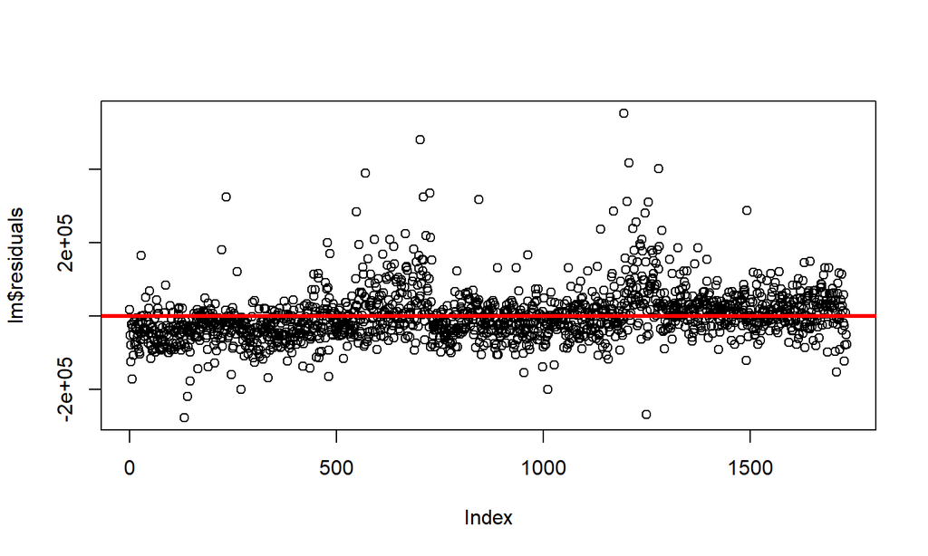

```r
# Checking assumtpions - Linearity and Homoskedacity


plot(lm$residuals)
abline(h=0, lwd = 3, col = "red")
```

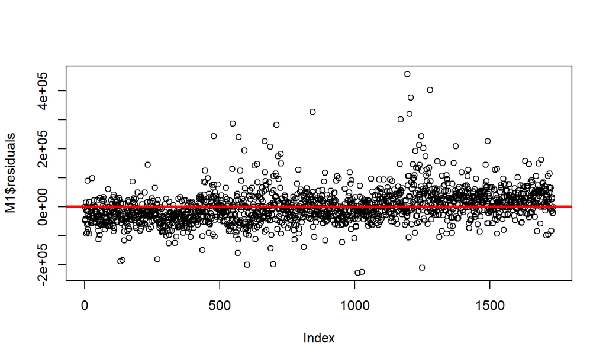

```r
plot(M1$residuals)
abline(h=0, lwd = 3, col = "red")
```

2. Independence: We take it for granted that the data has been independently collected.

1. Homoskedacity: In both models, it appears the variance is constant in the QQ plot for each error term and therefore the homoskedacity assumption is satisfied.
2. Normality: The majority of points lie close to the diagonal line in both QQ plots, however, there are many outliers in the upper tail so the normality assumption is moderately well satisfied. Furthermore, we have a large sample size, and so can use the central limit theorem to justify approximately valid inferences under a normality assumption.

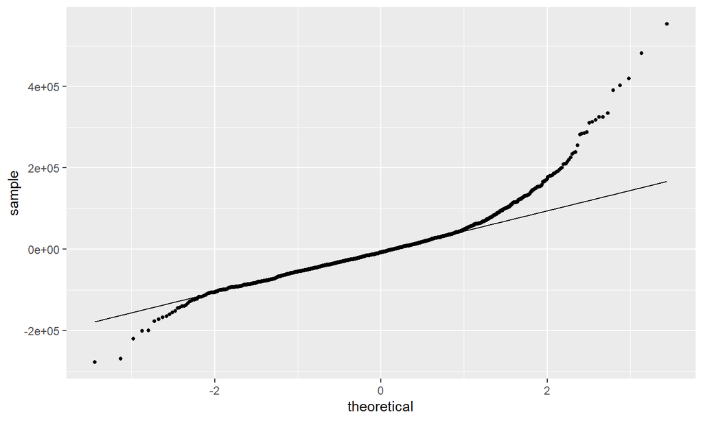

```r
# Checking assumptions - Normality

lm.res = lm$residuals
M1.res = M1$residuals

ggplot(data.frame(lm.res)) +
  aes(sample = lm.res) +
  geom_qq_line() +
  geom_qq(size=1)
```

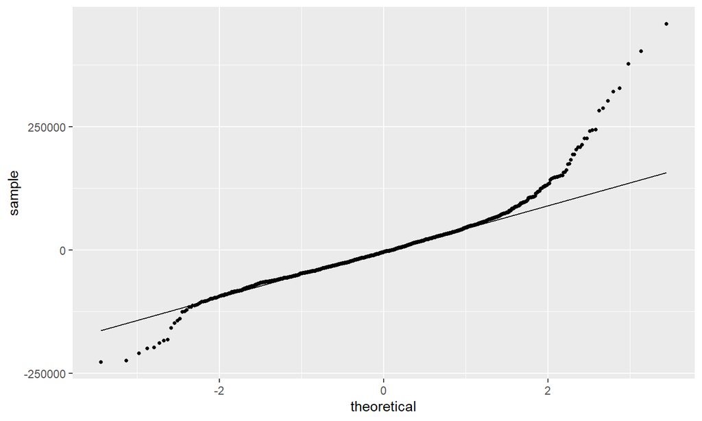

```r
ggplot(data.frame(M1.res)) +
  aes(sample = M1.res) +
  geom_qq_line() +
  geom_qq(size=1)
```

## Performance Analysis

Here we compare the performance of the multi-variate regression model to that of the simple linear regression model.

### In-sample Performance

Simple Model Performance: 0.5090615 Multivariate Model Performance: 0.6554742

### Out of Sample Performance

```r
set.seed(2)
n = nrow(houses)
```

```r
n_train = floor(0.8*n)
n_test = n - n_train
grp_labs = rep(c("Train", "Test"), times = c(n_train, n_test))
houses$grp = sample(grp_labs)
train_dat = houses %>% filter(grp == "Train")

lm_simple_train = lm(Price ~ Living.Area, data = train_dat)
lm_full_train = lm(formula = Price ~ Lot.Size + Waterfront + Age +
    Land.Value + New.Construct + Central.Air + Heat.Type + Living.Area +
    Bedrooms + Bathrooms + Rooms, data = train_dat)

test_dat = houses %>% filter(grp == "Test")
simple_pred = predict(lm_simple_train, newdata = test_dat)
full_pred = predict(lm_full_train, newdata = test_dat)
```

We compare the mean absolute error of the two models.  
MAE(Simple Model) = 4.6975154^{4}  
MAE(Full Model) = 4.1735764^{4}

```r
set.seed(2)
nrow(houses)
```

```
## [1] 1734
```

```r
houses$grp = NULL
fold_id = c(rep(1:17, each = 102))
houses$fold_id = sample(fold_id, replace = FALSE)
head(houses)
```

```
##    Price Lot.Size Waterfront Age Land.Value New.Construct Central.Air Fuel.Type
## 1 132500     0.09          0  42      50000             0           0  Electric
## 2 181115     0.92          0   0      22300             0           0       Gas
## 3 109000     0.19          0 133       7300             0           0       Gas
## 4 155000     0.41          0  13      18700             0           0       Gas
## 5  86060     0.11          0   0      15000             1           1       Gas
## 6 120000     0.68          0  31      14000             0           0       Gas
##   Heat.Type Sewer.Type Living.Area Pct.College Bedrooms Fireplaces Bathrooms
## 1  Electric    Private         906          35        2          1       1.0
## 2 Hot Water    Private        1953          51        3          0       2.5
## 3 Hot Water     Public        1944          51        4          1       1.0
## 4   Hot Air    Private        1944          51        3          1       1.5
## 5   Hot Air     Public         840          51        2          0       1.0
## 6   Hot Air    Private        1152          22        4          1       1.0
##   Rooms Test fold_id
## 1     5    0      10
## 2     6    1       7
## 3     8    1       8
## 4     5    0       5
## 5     3    0       4
## 6     8    1       3
```

```r
k = 10
simple_mse = full_mse = vector(mode = "numeric", length = k)
simple_mae = full_mae = vector(mode = "numeric", length = k)

for (i in 1:k) {
  test_set = houses[fold_id == i,]
  training_set = houses[fold_id != i,]
  simple_lm = lm(Price ~ Living.Area, data = training_set)
  simple_pred = predict(simple_lm, test_set)
  simple_mse[i] = mean((test_set$Price - simple_pred) ^ 2)
  simple_mae[i] = mean(abs(test_set$Price - simple_pred))
  full_lm = lm(formula = Price ~ Lot.Size + Waterfront + Age +
    Land.Value + New.Construct + Central.Air + Heat.Type + Living.Area +
    Bedrooms + Bathrooms + Rooms, data = training_set)
  full_pred = predict(full_lm, test_set)
  full_mse[i] = mean((test_set$Price - full_pred)^2)
  full_mae[i] = mean(abs(test_set$Price - full_pred))
}
```

```r
cv_res = tibble(simple_mse, full_mse, simple_mae, full_mae)
cv_res
```

```
## # A tibble: 10 × 4
##     simple_mse    full_mse simple_mae full_mae
##          <dbl>       <dbl>      <dbl>    <dbl>
##  1 4350291398. 2404970982.     56070.   41279.
##  2 4071602549. 2588422519.     45832.   37409.
##  3 4597620447. 2723501521.     48445.   41624.
##  4 3477389547. 2917113992.     48517.   46584.
##  5 3535437501. 2718914857.     44488.   38154.
##  6 6207607209. 5260560302.     53659.   52846.
##  7 9916195776. 5162839328.     67446.   51616.
##  8 4570604427. 2706730670.     47948.   36465.
##  9 2865715194. 2432856053.     36747.   32540.
## 10 3242569003. 2573917451.     42483.   38090.
```

```r
c(sqrt(mean(simple_mse)),
  sqrt(mean(full_mse))) %>% round(2)
```

```
## [1] 68436.13 56115.80
```

```r
c(mean(simple_mae),
  mean(full_mae)) %>% round(2)
```

```
## [1] 49163.63 41660.57
```

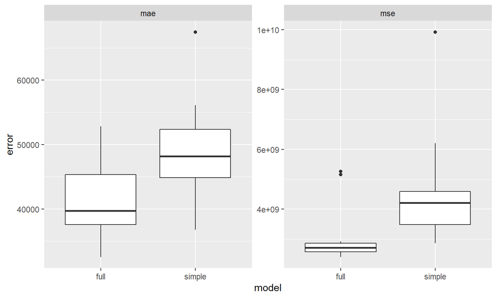

```r
cv_res %>% gather(key = "metric", value = "error") %>%
  separate(col = metric, into = c("model","metric")) %>%
  ggplot(aes(x = model, y = error)) + facet_wrap(~metric, scales = "free_y") +
  geom_boxplot()
```

```r
library(caret)
```

```r
cv_full = train(
  Price ~ Lot.Size + Waterfront + Age +
    Land.Value + New.Construct + Central.Air + Heat.Type + Living.Area +
    Bedrooms + Bathrooms + Rooms, houses,
  method = "lm",
  trControl = trainControl(
    method = "cv", number = 10,
    verboseIter = FALSE
  )
)
cv_full
```

```
## Linear Regression
##
## 1734 samples
##   11 predictor
##
## No pre-processing
## Resampling: Cross-Validated (10 fold)
## Summary of sample sizes: 1561, 1560, 1561, 1560, 1561, 1562, ...
## Resampling results:
##
##   RMSE      Rsquared   MAE
##   57831.41  0.6515982  41376.38
##
## Tuning parameter 'intercept' was held constant at a value of TRUE
```

```r
cv_simple = train(
  Price ~ Living.Area,
  houses,
  method = "lm",
  trControl = trainControl(
    method = "cv", number = 10,
    verboseIter = FALSE
  )
)
cv_simple
```

```
## Linear Regression
##
## 1734 samples
##    1 predictor
##
## No pre-processing
## Resampling: Cross-Validated (10 fold)
## Summary of sample sizes: 1560, 1562, 1560, 1561, 1561, 1561, ...
## Resampling results:
##
##   RMSE      Rsquared   MAE
##   68633.94  0.5160882  47811.22
##
## Tuning parameter 'intercept' was held constant at a value of TRUE
```